# Data Visualization: Ford Go Bike 2017

## Question 3.

#### What is the distribution of trip duration by month, week and day?

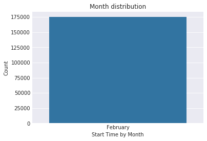

```python
# 3. Barchart
# distribution of trip duration by month
base_color = sb.color_palette()[0]
sb.countplot(data=gobikes, x='start_month', color=base_color)
plt.xlabel('Start Time by Month')
plt.ylabel('Count')
plt.title('Month distribution');
```

February is the only month present in this dataset

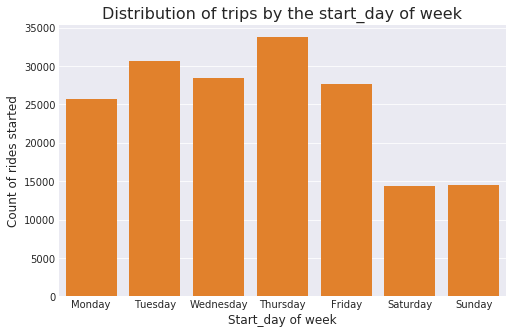

```python
# 3. Barchart
# distribution of trip duration by days
plt.figure(figsize=(8,5))
base_color = sb.color_palette()[1]

weekday = ['Monday', 'Tuesday', 'Wednesday', 'Thursday', 'Friday', 'Saturday', 'Sunday']
weekdaycat = pd.api.types.CategoricalDtype(ordered=True, categories=weekday)
gobikes['start_weekday'] = gobikes['start_weekday'].astype(weekdaycat)

sb.countplot(data=gobikes, x='start_weekday', color=base_color)
plt.xlabel('Start_day of week', fontsize=12)
plt.ylabel('Count of rides started', fontsize=12)
plt.title("Distribution of trips by the start_day of week", fontsize=16);
```

the above plot shows that number of bike trips is on almost similar level during weekdays with Thursday having the highest trip, it however drops to around 50% on weekends.

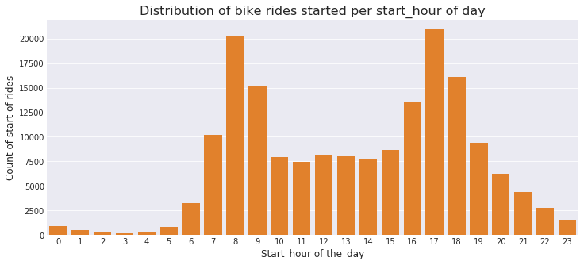

```python
# 3. Barchart
# distribution of trip duration by hours
plt.figure(figsize=(12,5))
base_color = sb.color_palette()[1]
sb.countplot(data=gobikes, x='start_hour', color=base_color)
plt.xlabel('Start_hour of the_day', fontsize=12)
plt.ylabel('Count of start of rides', fontsize=12)
plt.title('Distribution of bike rides started per start_hour of day', fontsize=16);
```

the plot shows that The distribution of starting a bike trip has a bimodal distribution:

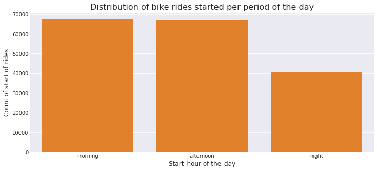

```python
# 3. Barchart
# distribution of trip duration by hours
plt.figure(figsize=(12,5))
base_color = sb.color_palette()[1]
sb.countplot(data=gobikes, x='period_day', color=base_color)
plt.xlabel('Start_hour of the_day', fontsize=12)
plt.ylabel('Count of start of rides', fontsize=12)
plt.title('Distribution of bike rides started per period of the day', fontsize=16);
```

This plot above shows that morning and afternoon are the peak periods showing many people would have been home by night.

## Question 4.

#### What is the distribution of usertype?

```python
gobikes.user_type.value_counts()
```

```
Subscriber    158386
Customer       16566
Name: user_type, dtype: int64
```

[figure not shown]

```python
# 4. Piechart
# to identify the distribution of user type.
labels = list(gobikes.user_type.unique())
sizes = gobikes.user_type.value_counts()
explode = (0.16, 0)

fig1, ax1 = plt.subplots()
ax1.pie(sizes, labels=labels, autopct='%1.1f%%',
        shadow=True, startangle=90 , explode = explode )

ax1.axis('equal')
plt.tight_layout()
plt.title('User type distribution')
plt.show()
```

The majority of the bikers are subscribers.

## Question 5.

#### What is the distribution of member gender?

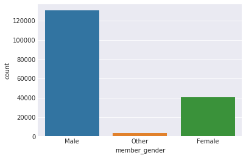

```python
# 5. Barchart
# count of member gender
sb.countplot(data=gobikes,x='member_gender');
```

This confirm my assumption that male users are more than the female users. However, it will be interesting to know who are the 'others".

```python
# Take a look at the 'Other' group in gender.
gobikes.query('member_gender == "Other"')
```

[output not shown]

3647 rows × 24 columns

It's not clear that the riders are not willing to reveal or there are data entry issues.

## Question 6.

#### What is the distribution of users age?

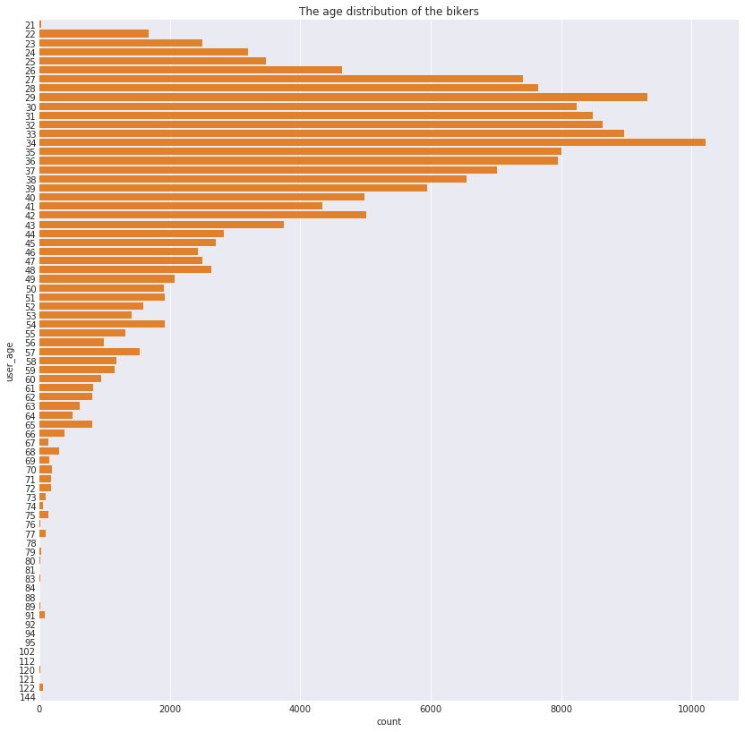

```
0    34
dtype: int64
37.1968654259
```

```python
# 6. Barchart
# To identify the distribution of bikers ages.

base_color = sb.color_palette()[1]
plt.figure(figsize=[14, 14])

ax = sb.countplot(data = gobikes, y = 'user_age', color = base_color)
# Set title
ax.set_title("The age distribution of the bikers")
plt.show()
print(gobikes.user_age.mode())
print(gobikes.user_age.mean())
```

The distribution is right skewed , the mode is 34 and the mean is 37.2.

I already assumed the young users will be more than the old users and this has confirmed it.

## Question 7.

#### What is the distribution of count of trips to station_names?

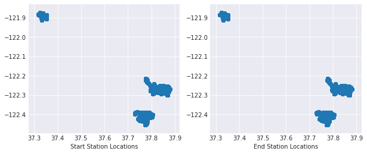

```python
# 7. Scatter plot
# plot the distribution of location

plt.figure(figsize=[10, 4])

plt.subplot(1, 2, 1)
plt.scatter(data=gobikes, x='start_station_latitude', y='start_station_longitude')
plt.xlabel('Start Station Locations')

plt.subplot(1, 2, 2)
plt.scatter(data=gobikes, x='end_station_latitude', y='end_station_longitude')
plt.xlabel('End Station Locations');
```

Start location and end location have the same distribution. What this means is that the distances are not very far.

```python
# Location: there are 329 start stations.
print(len(gobikes['start_station_name'].value_counts()))
gobikes['start_station_name'].value_counts()
```

```
329
```

```
Market St at 10th St                                               3649
San Francisco Caltrain Station 2  (Townsend St at 4th St)          3408
Berry St at 4th St                                                 2952
Montgomery St BART Station (Market St at 2nd St)                   2711
Powell St BART Station (Market St at 4th St)                       2620
San Francisco Caltrain (Townsend St at 4th St)                     2577
San Francisco Ferry Building (Harry Bridges Plaza)                 2541
Howard St at Beale St                                              2216
Steuart St at Market St                                            2191
Powell St BART Station (Market St at 5th St)                       2144
The Embarcadero at Sansome St                                      1975
Bancroft Way at Telegraph Ave                                      1761
Bancroft Way at College Ave                                        1712
2nd St at Townsend St                                              1702
Beale St at Harrison St                                            1678
3rd St at Townsend St                                              1675
Embarcadero BART Station (Beale St at Market St)                   1646
4th St at Mission Bay Blvd S                                       1496
Townsend St at 7th St                                              1479
Civic Center/UN Plaza BART Station (Market St at McAllister St)    1476
The Embarcadero at Steuart St                                      1420
Downtown Berkeley BART                                             1322
Post St at Kearny St                                               1311
4th St at 16th St                                                  1274
Howard St at 8th St                                                1257
19th Street BART Station                                           1231
Esprit Park                                                        1226
Rhode Island St at 17th St                                         1224
Hearst Ave at Euclid Ave                                           1176
8th St at Brannan St                                               1154
                                                                   ...
45th St at MLK Jr Way                                                54
27th St at MLK Jr Way                                                54
Mendell St at Fairfax Ave                                            53
San Antonio Park                                                     53
Locust St at Grant St                                                49
Williams Ave at 3rd St                                               48
Delmas Ave and San Fernando St                                       47
San Carlos St at Market St                                           37
Lane St at Revere Ave                                                36
Foothill Blvd at Harrington Ave                                      35
Mission St at 1st St                                                 32
Almaden Blvd at Balbach St                                           32
George St at 1st St                                                  31
Oak St at 1st St                                                     30
Empire St at 7th St                                                  28
SAP Center                                                           27
Williams Ave at Apollo St                                            25
Foothill Blvd at 42nd Ave                                            23
San Pedro St at Hedding St                                           19
26th Ave at International Blvd                                       19
23rd Ave at Foothill Blvd                                            17
Backesto Park (Jackson St at 13th St)                                17
Leavenworth St at Broadway                                           16
Taylor St at 9th St                                                  13
Farnam St at Fruitvale Ave                                            9
Willow St at Vine St                                                  9
Parker Ave at McAllister St                                           7
21st Ave at International Blvd                                        4
Palm St at Willow St                                                  3
16th St Depot                                                         2
Name: start_station_name, Length: 329, dtype: int64
```

There are 329 stations in this dataset. I will look into Top 10 stations with the most trips.

```python
# How does traffic at end stations look like?
print(len(gobikes['end_station_name'].value_counts()))
gobikes['end_station_name'].value_counts()
```

```
329
```

```
San Francisco Caltrain Station 2  (Townsend St at 4th St)          4624
Market St at 10th St                                               3709
Montgomery St BART Station (Market St at 2nd St)                   3461
San Francisco Ferry Building (Harry Bridges Plaza)                 3151
San Francisco Caltrain (Townsend St at 4th St)                     2870
Powell St BART Station (Market St at 4th St)                       2854
Berry St at 4th St                                                 2782
The Embarcadero at Sansome St                                      2341
Steuart St at Market St                                            2264
Powell St BART Station (Market St at 5th St)                       2153
Howard St at Beale St                                              1970
Beale St at Harrison St                                            1780
Bancroft Way at Telegraph Ave                                      1780
Civic Center/UN Plaza BART Station (Market St at McAllister St)    1733
2nd St at Townsend St                                              1667
3rd St at Townsend St                                              1628
Embarcadero BART Station (Beale St at Market St)                   1622
4th St at Mission Bay Blvd S                                       1590
Townsend St at 7th St                                              1440
The Embarcadero at Steuart St                                      1414
19th Street BART Station                                           1392
Post St at Kearny St                                               1366
Downtown Berkeley BART                                             1321
Rhode Island St at 17th St                                         1271
8th St at Brannan St                                               1270
Folsom St at 3rd St                                                1247
Howard St at 8th St                                                1216
Esprit Park                                                        1182
4th St at 16th St                                                  1135
Spear St at Folsom St                                              1116
                                                                   ...
Williams Ave at 3rd St                                               50
Market St at 40th St                                                 48
27th St at MLK Jr Way                                                48
Lane St at Revere Ave                                                46
Locust St at Grant St                                                45
Empire St at 1st St                                                  45
San Carlos St at Market St                                           42
Bestor Art Park                                                      38
SAP Center                                                           37
10th Ave at E 15th St                                                35
Almaden Blvd at Balbach St                                           34
George St at 1st St                                                  33
San Pedro St at Hedding St                                           30
Oak St at 1st St                                                     28
Empire St at 7th St                                                  25
Mission St at 1st St                                                 24
Foothill Blvd at 42nd Ave                                            20
Williams Ave at Apollo St                                            20
23rd Ave at Foothill Blvd                                            19
26th Ave at International Blvd                                       19
Backesto Park (Jackson St at 13th St)                                18
Foothill Blvd at Harrington Ave                                      16
Leavenworth St at Broadway                                           12
Taylor St at 9th St                                                  11
Farnam St at Fruitvale Ave                                           10
Parker Ave at McAllister St                                           9
Palm St at Willow St                                                  7
16th St Depot                                                         6
Willow St at Vine St                                                  5
21st Ave at International Blvd                                        5
Name: end_station_name, Length: 329, dtype: int64
```

```python
# I subset the dataset by keeping only top 10 locations with high traffics, df_top10.
locs = ['Market St at 10th St','San Francisco Caltrain Station 2  (Townsend St at 4th St)','Berry St at 4th St','Montgomery St BART Station (Market St at 2nd St)','Powell St BART Station (Market St at 4th St)','San Francisco Caltrain (Townsend St at 4th St)','San Francisco Ferry Building (Harry Bridges Plaza)','Howard St at Beale St', 'Steuart St at Market St', 'Powell St BART Station (Market St at 5th St)']
df_top10 = gobikes.loc[gobikes['start_station_name'].isin(locs)]
```

```python
# Test and see if only keep top 10 station
df_top10['start_station_name'].value_counts()
```

```
Market St at 10th St                                         3649
San Francisco Caltrain Station 2  (Townsend St at 4th St)    3408
Berry St at 4th St                                           2952
Montgomery St BART Station (Market St at 2nd St)             2711
Powell St BART Station (Market St at 4th St)                 2620
San Francisco Caltrain (Townsend St at 4th St)               2577
San Francisco Ferry Building (Harry Bridges Plaza)           2541
Howard St at Beale St                                        2216
Steuart St at Market St                                      2191
Powell St BART Station (Market St at 5th St)                 2144
Name: start_station_name, dtype: int64
```

```python
# After subsetting top 10 station with the most trip, create a countplot to see the distribution and order from top 1 to top 10
st_stat_counts = df_top10['start_station_name'].value_counts()
st_stat_order = st_stat_counts.index
```

## Question 8.

#### Where are the top start stations?

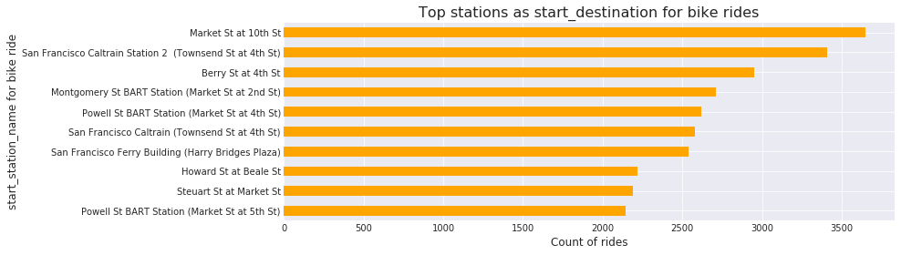

```python
# 8. Barchart
# Top 10 start station name for bike ride
plt.figure(figsize=(12,4))
sb.set_style('darkgrid')
df_top10['start_station_name'].value_counts().sort_values(ascending=True).plot(kind='barh', color='orange');
plt.title('Top stations as start_destination for bike rides', fontsize=16)
plt.xlabel('Count of rides', fontsize=12)
plt.ylabel('start_station_name for bike ride', fontsize=12);
```

```python
# let us limit to the top 10 destinations:
top_dest = gobikes['end_station_name'].value_counts().index[:10]
```

```python
# here we create dataframe with trips only to top 10 destinations
top_dest_df = gobikes.loc[gobikes['end_station_name'].isin(top_dest)]
top_dest_df.sample(5)
```

|  | duration_sec | start_time | end_time | start_station_id | start_station_name | start_station_latitude | start_station_longitude | end_station_id | end_station_name | end_station_latitude | ... | member_gender | bike_share_for_all_trip | duration_min | start_date | start_hour | start_weekday | start_month | year_month | period_day | user_age |
| --- | --- | --- | --- | --- | --- | --- | --- | --- | --- | --- | --- | --- | --- | --- | --- | --- | --- | --- | --- | --- | --- |
| 155555 | 621 | 2019-02-06 08:40:59.360 | 2019-02-06 08:51:21.095 | 28.0 | The Embarcadero at Bryant St | 37.787168 | -122.388098 | 3.0 | Powell St BART Station (Market St at 4th St) | 37.786375 | ... | Male | No | 10.350000 | 2019-02-06 | 8 | Wednesday | February | 2019-02 | morning | 30 |
| 113835 | 494 | 2019-02-12 10:45:57.533 | 2019-02-12 10:54:11.642 | 24.0 | Spear St at Folsom St | 37.789677 | -122.390428 | 67.0 | San Francisco Caltrain Station 2 (Townsend St... | 37.776639 | ... | Male | No | 8.233333 | 2019-02-12 | 10 | Tuesday | February | 2019-02 | morning | 33 |
| 1513 | 843 | 2019-02-28 18:55:48.765 | 2019-02-28 19:09:52.574 | 16.0 | Steuart St at Market St | 37.794130 | -122.394430 | 67.0 | San Francisco Caltrain Station 2 (Townsend St... | 37.776639 | ... | Male | No | 14.050000 | 2019-02-28 | 18 | Thursday | February | 2019-02 | night | 37 |
| 122533 | 395 | 2019-02-11 11:37:59.663 | 2019-02-11 11:44:35.339 | 126.0 | Esprit Park | 37.761634 | -122.390648 | 81.0 | Berry St at 4th St | 37.775880 | ... | Male | No | 6.583333 | 2019-02-11 | 11 | Monday | February | 2019-02 | morning | 43 |
| 31552 | 1108 | 2019-02-24 16:20:05.707 | 2019-02-24 16:38:33.928 | 61.0 | Howard St at 8th St | 37.776513 | -122.411306 | 15.0 | San Francisco Ferry Building (Harry Bridges Pl... | 37.795392 | ... | Female | No | 18.466667 | 2019-02-24 | 16 | Sunday | February | 2019-02 | afternoon | 27 |

5 rows × 24 columns

## Question 9.

#### Where are the top destinations?

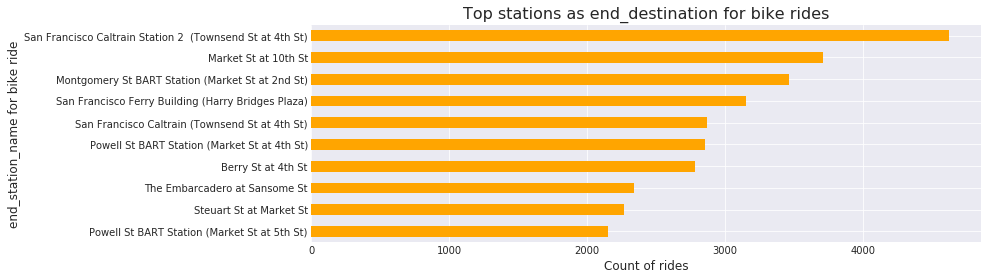

```python
# 9. Barchart
# Top 10 end station name for bike ride
plt.figure(figsize=(12,4))
sb.set_style('darkgrid')
top_dest_df['end_station_name'].value_counts().sort_values(ascending=True).plot(kind='barh', color='orange');
plt.title('Top stations as end_destination for bike rides', fontsize=16)
plt.xlabel('Count of rides', fontsize=12)
plt.ylabel('end_station_name for bike ride', fontsize=12);
```

After checking start and end stations, most stations in San Francisco connect to public transportations.

### Discuss the distribution(s) of your variable(s) of interest. Were there any unusual points? Did you need to perform any transformations?

> - A. starttime and endtime have the wrong datatype string (instead of datetime)
> - B. start_station_id has wong datatype int64 (instead of str)
> - C. user_type has wrong datatype string (instead of categorical)
> - D. There is 17,318 missing values presented in 6 columns in the dataset (start_station_id, start_station_name, end_station_id, end_station_name, member_birth_year and Member_gender).

## Bivariate Exploration

This is section where I investigate relationships between pairs of variables in the data.

## Question 10.

#### What is the relationship between trip duration and users age?

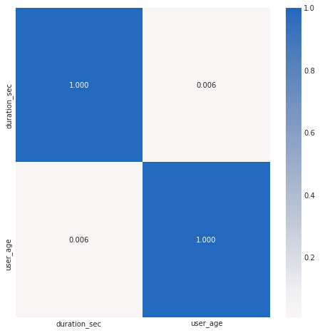

```python
# 10. Heat map display correlation between age and duration
numeric_vars = ['duration_sec', 'user_age']
plt.figure(figsize = [8, 8])
sb.heatmap(gobikes[numeric_vars].corr(), annot = True, fmt = '.3f',cmap = 'vlag_r', center = 0)
plt.show()
```

There is no significant relationship between trip duration and user`s age. This information really does not tell much.

## Question 11.

#### What is the relationship between trip duration and users gender?

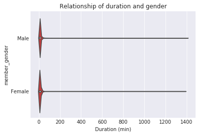

```python
# 11. Violin plot
# Relatioship between duration and gender
base_color = sb.color_palette()[3]
sb.violinplot(data = gobikes[gobikes['member_gender'] != "Other"], y = 'member_gender', x = 'duration_min', color = base_color )
plt.xlabel('Duration (min)')
plt.title('Relationship of duration and gender')
plt.show()
```

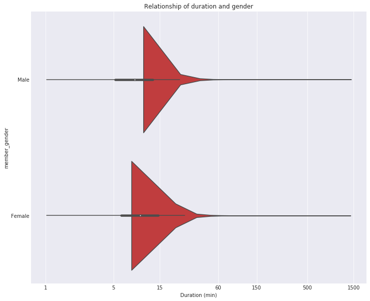

```python
#I use large sample size to further interpret the plot.
#Sample of 100k values.
log_binsize = 0.025
bins = 10 ** np.arange(2.4, np.log10(gobikes['duration_min'].max())+log_binsize, log_binsize)
plt.figure(figsize=(12,10))
samples = np.random.choice(gobikes.shape[0], 100000, replace = False);
bike_samp = gobikes.iloc[samples,:];
base_color = sb.color_palette()[3]
plt.xscale('log')
sb.violinplot(data = bike_samp[bike_samp['member_gender'] != "Other"] , y = 'member_gender', x = 'duration_min', color = base_color )
plt.xlabel('Duration (min)')
plt.title('Relationship of duration and gender')
plt.xticks([1, 5, 15 , 60 , 150 , 500 , 1500] , [1, 5, 15 , 60 , 150 , 500 , 1500])
plt.show()
```

```python
#evaluate the mean.
male = gobikes[gobikes['member_gender'] == "Male"]
female = gobikes[gobikes['member_gender'] == "Female"]
print(male.duration_min.mean() , female.duration_min.mean())
```

```
11.2065808429 12.9812126782
```

The violin plot above shows the females stay longer on the bikes. might be because they ride slower than the males.

## Question 12.

#### How did the user types take bike rides over the week/hours?

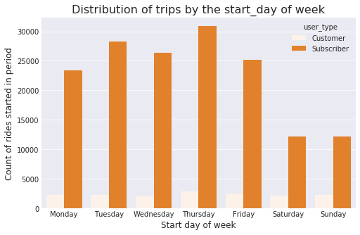

```python
# 12. Barchart
# Comparing the usage profile of user_types over the day_of_week and hour_of_day

plt.figure(figsize=(8,5))
base_color = sb.color_palette()[1]

weekday = ['Monday', 'Tuesday', 'Wednesday', 'Thursday', 'Friday', 'Saturday', 'Sunday']
weekdaycat = pd.api.types.CategoricalDtype(ordered=True, categories=weekday)
gobikes['start_weekday'] = gobikes['start_weekday'].astype(weekdaycat)

sb.countplot(data=gobikes, x='start_weekday', hue='user_type', color=base_color)
plt.xlabel('Start day of week', fontsize=12)
plt.ylabel('Count of rides started in period', fontsize=12)
plt.title("Distribution of trips by the start_day of week", fontsize=16);
```

Look into the daily profile:

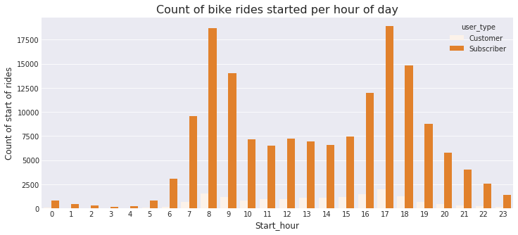

```python
# 12. Barchart
# Comparing the usage profile of user_types over the day_of_week and hour_of_day
plt.figure(figsize=(12,5))
base_color = sb.color_palette()[1]
sb.countplot(data=gobikes, x='start_hour', hue='user_type', color=base_color)
plt.xlabel('Start_hour', fontsize=12)
plt.ylabel('Count of start of rides', fontsize=12)
plt.title('Count of bike rides started per hour of day', fontsize=16);
```

## Question 13.

#### What is the duration per user type?

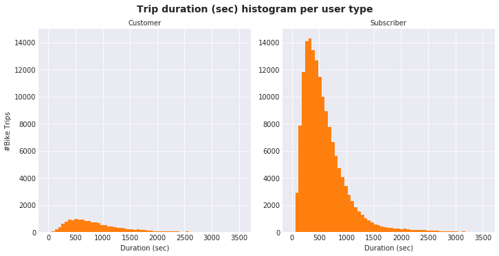

```python
# 13. Histogram
# Duration (sec) distribution per user type

g = sb.FacetGrid(gobikes, col="user_type", margin_titles=True, size=5)
bin_edges = np.arange(0, 3600,60)
g.map(plt.hist, "duration_sec", color=sb.color_palette()[1], bins=bin_edges)
g.set_axis_labels("Duration (sec)", "#Bike Trips")
g.set_titles(col_template = '{col_name}')
g.fig.suptitle('Trip duration (sec) histogram per user type', y=1.03, fontsize=14, fontweight='semibold');
```

Both distributions are rightly skewed. However, the subscribers have more bike trips because there are more subscribers than customers.

```python
# Prepare lists of numeric variables and categorical variables
numeric_vars = ['age','duration_sec']
times_chr = ['period_day','start_weekday','start_month']
users_chr = ['user_type','member_gender']
```

## Question 14.

#### What are the top start stations by hour/days?

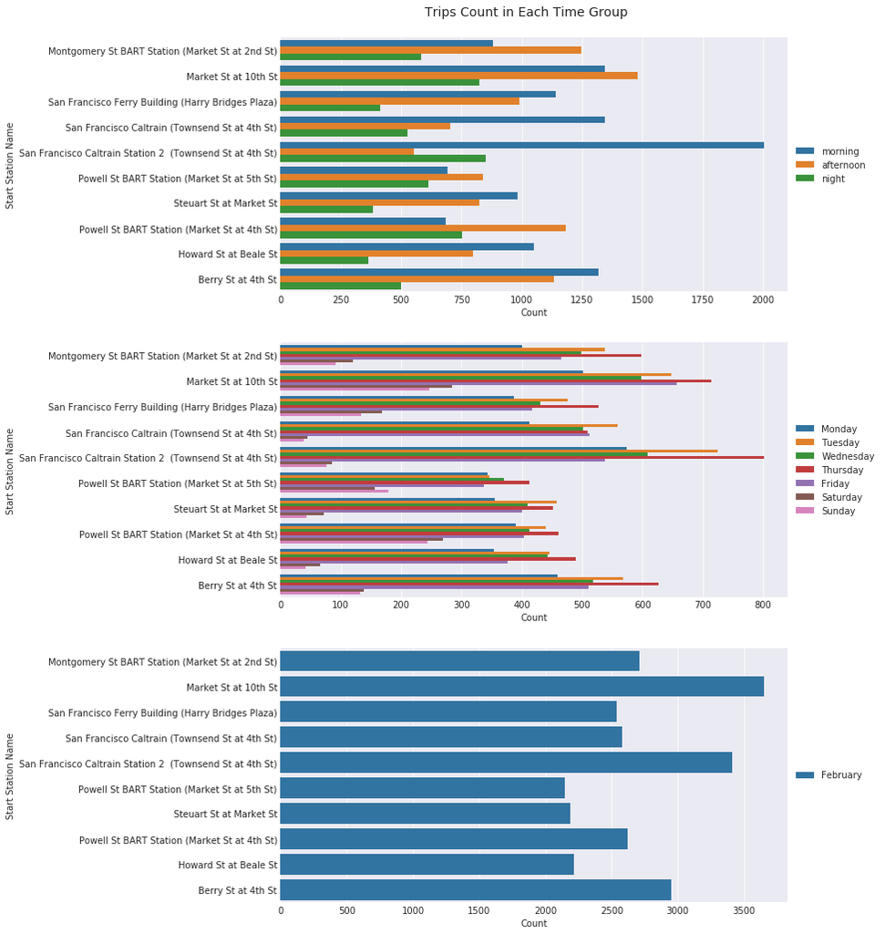

```python
# 14. Countplot
# Top 10 start stations by times (time of day, weekdays)
fig = plt.figure(figsize=(10,16))
plt.subplots_adjust(top=0.95)
fig.suptitle('Trips Count in Each Time Group', fontsize=14)
for i in range(1, 4):
    ax = fig.add_subplot(3, 1, i)
    sb.countplot(data=df_top10, y='start_station_name', hue=times_chr[i-1])
    plt.legend(loc='center left', bbox_to_anchor=(1,0.5))
    plt.ylabel('Start Station Name')
    plt.xlabel('Count');
```

## Question 15.

#### What is the top start stations by users attributes?

[figure not shown]

```python
# 15. Countplot
# Top 10 stations by users' attributes (user_type, member's gender)
fig = plt.figure(figsize=(10,10))
plt.subplots_adjust(top=0.95)
fig.suptitle('Trips Count in Each Rider\'s Characteristics' , fontsize=14)
for i in range(1, 3):
    ax = fig.add_subplot(2, 1, i)
    sb.countplot(data=df_top10, y='start_station_name', hue=users_chr[i-1])
    plt.legend(loc='center left', bbox_to_anchor=(1,0.5))
    plt.ylabel('Start Station Name')
    plt.xlabel('Count');
```

#### After breaking down into top 10 station by users' attributes:

- There are more customers at San Francisco Ferry Building (Harry Bridges Plaza), Powell St BART Station (Market St at 4th St) and Berry St at 4th St stations than at other stations.
- The trips in male riders are way more than in females.

## Question 16.

#### What are the top destinations by hours/weekdays?

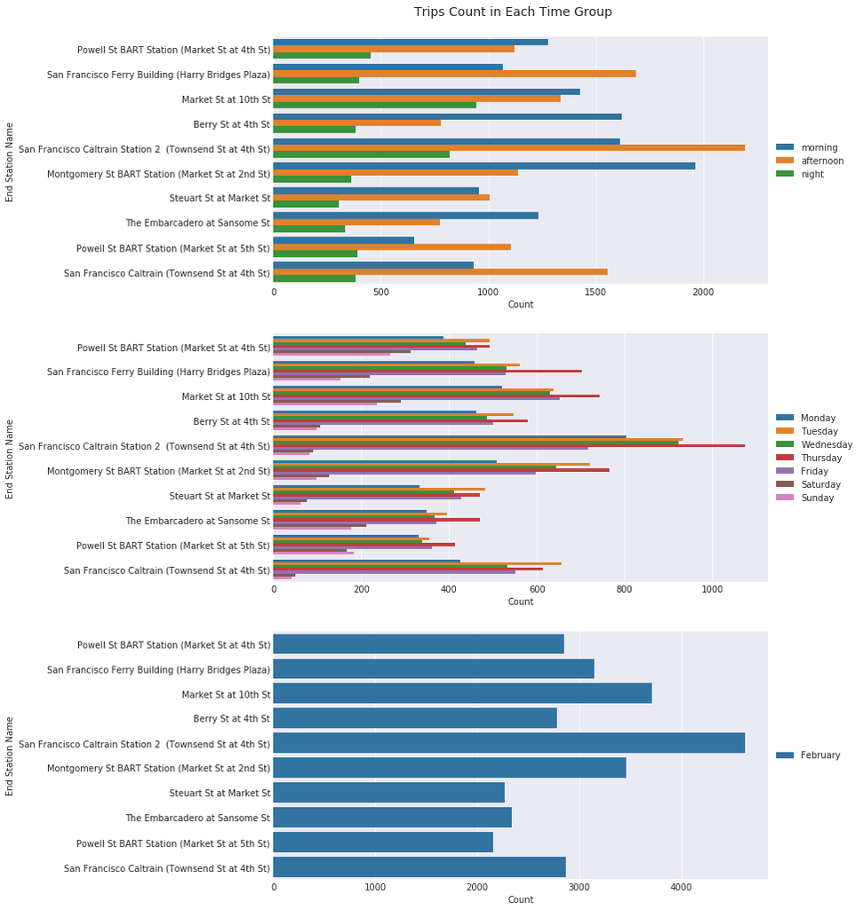

```python
# 16. Countplot
# Top 10 start stations by times (time of day, weekdays)
fig = plt.figure(figsize=(10,16))
plt.subplots_adjust(top=0.95)
fig.suptitle('Trips Count in Each Time Group', fontsize=14)
for i in range(1, 4):
    ax = fig.add_subplot(3, 1, i)
    sb.countplot(data=top_dest_df, y='end_station_name', hue=times_chr[i-1])
    plt.legend(loc='center left', bbox_to_anchor=(1,0.5))
    plt.ylabel('End Station Name')
    plt.xlabel('Count');
```

#### After breaking down into each station,

- Time of day: San Francisco Caltrain Station 2 (Townsend St at 4th St) has a significant higher end point that other stations in the afternoon. morning is not necessary the period of time with most trips. Half of stations have the most destination during the morning and another half of stations has the most destination during the afternoon.
- Day of week: weekdays (Tuesday and Thursday) have the most trips than other days. Weekdays still get more trips than weekends.

## Question 17.

#### What are the top destinations by users attributes?

[figure not shown]

```python
# 17. Countplot
# Top 10 stations by users' attributes (user_type, member's gender)
fig = plt.figure(figsize=(10,10))
plt.subplots_adjust(top=0.95)
fig.suptitle('Trips Count in Each Rider\'s Characteristics' , fontsize=14)
for i in range(1, 3):
    ax = fig.add_subplot(2, 1, i)
    sb.countplot(data=top_dest_df, y='end_station_name', hue=users_chr[i-1])
    plt.legend(loc='center left', bbox_to_anchor=(1,0.5))
    plt.ylabel('Destination')
    plt.xlabel('Count');
```

#### After breaking down into top 10 station by users' attributes:

- There are more customers at San Francisco Ferry Building (Harry Bridges Plaza), San Francisco Caltrain Station 2 (Townsend St at 4th St) and The Embarcadero at Sansome stations than at other stations.
- The trips in male riders are way more than in females.

## Question 18.

#### What are the top start stations by users age and duration of trips?

[figure not shown]

```python
# 8. Violin plot
# Top 10 stations by age, Top 10 stations by duration of trips
plt.figure(figsize=(8,10))
base_color = sb.color_palette()[0]
ax = plt.subplot(211)
sb.violinplot(data=df_top10, y='start_station_name', x='user_age', inner='quartile', color=base_color)
plt.xlabel('Age (year)')
plt.ylabel('Start Station Name')
plt.title('Age Distribution in Top 10 Stations')

ax = plt.subplot(212)
sb.violinplot(data=df_top10, y='start_station_name', x='duration_sec', inner='quartile',color=base_color)
plt.xlabel('Duration (sec)')
plt.ylabel('Start Station Name')
plt.title('Duration of Trips Distribution in Top 10 Stations');
```

[figure not shown]

```python
# Violin plot and box plot
# I will do log transform to further expand the data in the plot.

plt.figure(figsize=(8,10))
base_color = sb.color_palette()[0]
ax = plt.subplot(211)
sb.violinplot(data=df_top10, y='start_station_name', x='user_age', inner='quartile', color=base_color)
plt.xscale('log')
plt.xticks([10,20,30,35,40,50,70,90,100], [10,20,30,35,40,50,70,90,100])
plt.ylabel('Start Station Name')
plt.xlabel('Age (year)')
plt.title('Log-Age Distribution in Top 10 Stations')

ax = plt.subplot(212)
sb.boxplot(data=df_top10, y='start_station_name', x='duration_sec',color=base_color)
plt.xscale('log')
plt.xticks([10,50,100,650,1000,1500,2000,4000,6000,10000], [10,70,100,650,'1K','1.5K','2K','4K','6K','10K'])
plt.xlabel('Duration (sec)')
plt.ylabel('Start Station Name')
plt.title('Duration of Trips Distribution in Top 10 Stations');
```

```python
# Check high outliers in duration of trips
len(df_top10.query('duration_sec > 1500')['duration_sec'])/len(df_top10['duration_sec'])
```

```
0.04061609093265208
```

After log-transformed, most of median age population (between 30 to 40) is consistent in each station. The median of duration (second) falls around 650 second. However, after 1500 second, there are a lot of high outliers around 4.1%.

```python
#Evaluate the mean .
yes = gobikes[gobikes['bike_share_for_all_trip'] == "Yes"]
no = gobikes[gobikes['bike_share_for_all_trip'] == "No"]
print(yes.duration_min.mean() , no.duration_min.mean())
```

```
11.399958684 11.7700750606
```

Bike sharing does not have influence on duration per trip.

## Observation

> Market St at 10th St and San Francisco Caltrain Station 2 (Townsend St at 4th St) are the most popular start points with San Francisco Caltrain Station 2 (Townsend St at 4th St) and Market St at 10th St are the most popular destinations. However, there are more customers at San Francisco Ferry Building (Harry Bridges Plaza), Powell St BART Station (Market St at 4th St), and Berry St at 4th St stations than at other stations. There are more customers going to San Francisco Ferry Building (Harry Bridges Plaza), San Francisco Caltrain Station 2 (Townsend St at 4th St) and The Embarcadero at Sansome stations than at other stations. San Francisco Ferry Building (Harry Bridges Plaza) seems to be a very popular place for customers. This suggests it,s a tourist attraction site.

> The males also take more bike rides than females even though the females use more duration during the bike rides. The users with age 27 - 37 take the bike rides more. This suggests they mostly take bike rides to work.

## Multivariate Exploration

This is where I will be creating plots of three or more variables to investigate the data further. I am interested in locations and time with most trips.

## Question 19.

#### how does the hourly usage varies during a week for Customers and Subscribers?

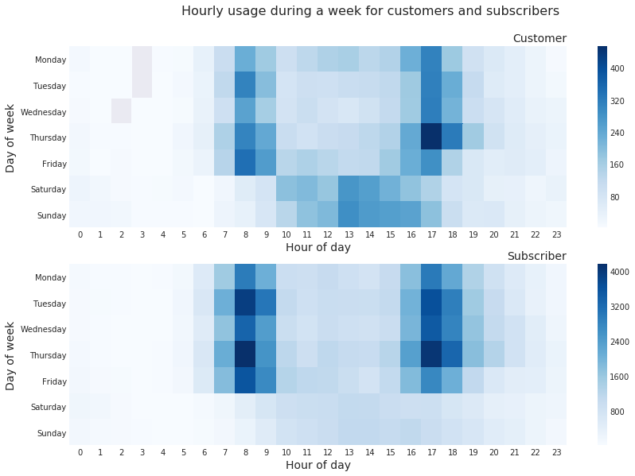

```python
# 19 barchart
# Hourly usage varies during a week for Customers and Subscribers

plt.figure(figsize=(14,9))

plt.subplot(2, 1, 1)
customers = gobikes.query('user_type == "Customer"')
ct_counts = customers.groupby(['start_weekday', 'start_hour']).size()
ct_counts = ct_counts.reset_index(name='count')
ct_counts = ct_counts.pivot(index='start_weekday', columns='start_hour', values='count')
sb.heatmap(ct_counts, cmap="Blues");
plt.title('Customer', loc='right', fontsize=14);
plt.xlabel('Hour of day', fontsize=14);
plt.ylabel('Day of week', fontsize=14);

plt.subplot(2, 1, 2)
subscribers = gobikes.query('user_type == "Subscriber"')
st_counts = subscribers.groupby(['start_weekday', 'start_hour']).size()
st_counts = st_counts.reset_index(name='count')
st_counts = st_counts.pivot(index='start_weekday', columns='start_hour', values='count')
sb.heatmap(st_counts, cmap="Blues");
plt.title('Subscriber', loc='right', fontsize=14);
plt.xlabel('Hour of day', fontsize=14);
plt.ylabel('Day of week', fontsize=14);

plt.subplots_adjust(top=0.9)
plt.suptitle('Hourly usage during a week for customers and subscribers', fontsize=16);
```

## Question 20.

#### Where are the top start stations for Customers and Subscribers?

```python
# 20 Top trip stations by times: separate user types and take a look customers and subscribers individually
df_cust = df_top10.query('user_type == "Customer"')
```

```python
df_sub = df_top10.query('user_type == "Subscriber"')
```

[figure not shown]

```python
# 3 categorical variables using countplot: time of day: morning, afternoon, night between customers and subscribers
plt.figure(figsize=(12,10))
ax = plt.subplot(211)
sb.countplot(data=df_cust, y='start_station_name', hue='period_day')
plt.legend(loc='center left', bbox_to_anchor=(1,0.5))
plt.title('Top 10 Trip Stations by Time of Day in Customers')
plt.xlabel('Count')
plt.ylabel('Start Station Name')

ax = plt.subplot(212)
sb.countplot(data=df_sub, y='start_station_name', hue='period_day')
plt.legend(loc='center left', bbox_to_anchor=(1,0.5))
plt.title('Top 10 Trip Stations by Time of Day in Subscribers')
plt.xlabel('Count')
plt.ylabel('Start Station Name');
```

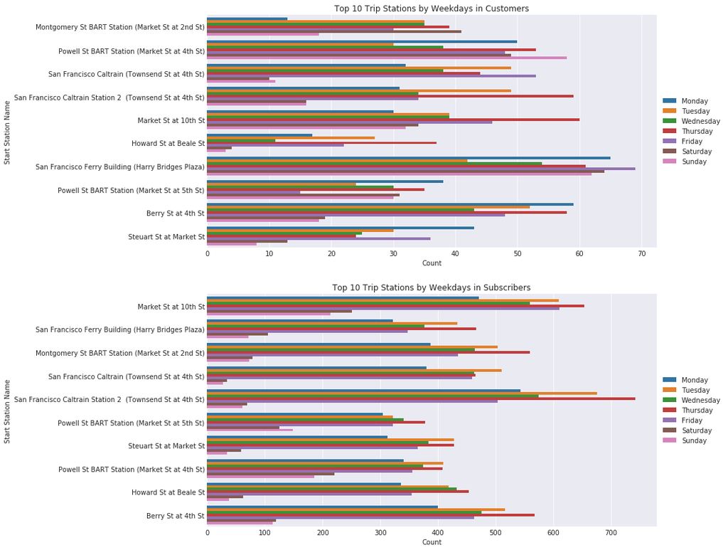

```python
# 3 categorical variables using countplot: Weekday between customers and subscribers
plt.figure(figsize=(12,14))
ax = plt.subplot(211)
sb.countplot(data=df_cust, y='start_station_name', hue='start_weekday')
plt.legend(loc='center left', bbox_to_anchor=(1,0.5))
plt.title('Top 10 Trip Stations by Weekdays in Customers')
plt.ylabel('Start Station Name')
plt.xlabel('Count')

ax = plt.subplot(212)
sb.countplot(data=df_sub, y='start_station_name', hue='start_weekday')
plt.legend(loc='center left', bbox_to_anchor=(1,0.5))
plt.title('Top 10 Trip Stations by Weekdays in Subscribers')
plt.ylabel('Start Station Name')
plt.xlabel('Count');
```

## Question 20.

#### What is the distribution of trip duration over respectively start_day_of_week and top destination end_station_name?

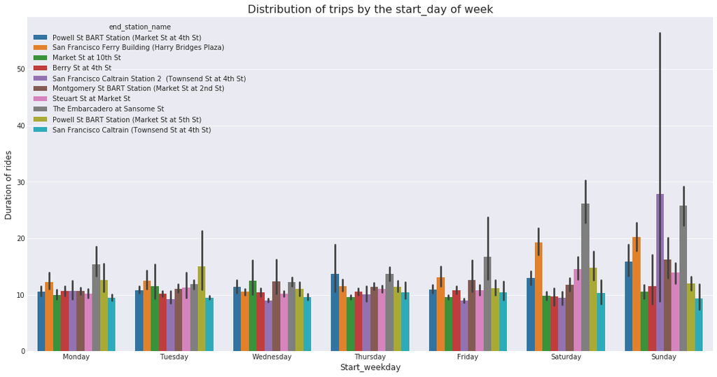

```python
plt.figure(figsize=(18,9))
base_color = sb.color_palette()[1]

weekday = ['Monday', 'Tuesday', 'Wednesday', 'Thursday', 'Friday', 'Saturday', 'Sunday']
weekdaycat = pd.api.types.CategoricalDtype(ordered=True, categories=weekday)
top_dest_df['start_weekday'] = top_dest_df['start_weekday'].astype(weekdaycat)

sb.barplot(data=top_dest_df, x='start_weekday', y='duration_min', hue='end_station_name')
plt.xlabel('Start_weekday', fontsize=12)
plt.ylabel('Duration of rides', fontsize=12)
plt.title("Distribution of trips by the start_day of week", fontsize=16);
```

Trip duration seems to be around the same except for The Embarcadero at Sansome St. This has probably a relation with the surrounding area (SF Bay leisure areas) and longer corresponding trip distances.

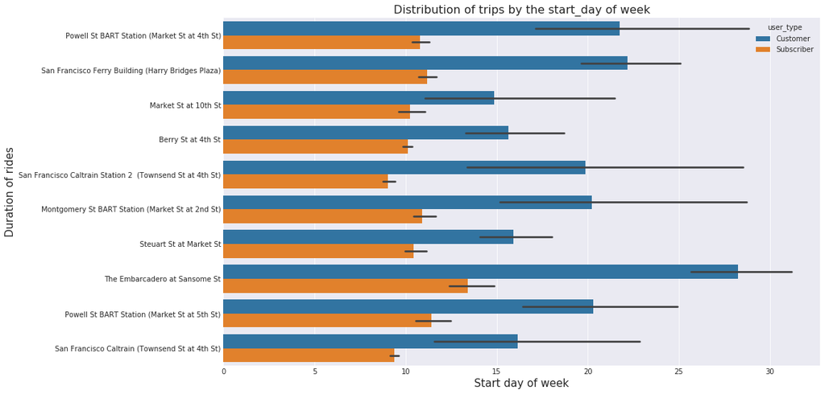

```python
plt.figure(figsize=(15,9))
base_color = sb.color_palette()[1]

weekday = ['Monday', 'Tuesday', 'Wednesday', 'Thursday', 'Friday', 'Saturday', 'Sunday']
weekdaycat = pd.api.types.CategoricalDtype(ordered=True, categories=weekday)
top_dest_df['start_weekday'] = top_dest_df['start_weekday'].astype(weekdaycat)

sb.barplot(data=top_dest_df, y='end_station_name', x='duration_min', hue='user_type')
plt.xlabel('Start day of week', fontsize=15)
plt.ylabel('Duration of rides', fontsize=15)
plt.title("Distribution of trips by the start_day of week", fontsize=16);
```

This shows that the long trip duration to The Embarcadero at Sansome St is mainly caused by customers.

[figure not shown]

```python
from IPython.display import Image
Image(filename='Sansome.png')
```

### Were there any interesting or surprising interactions between features?

> Based on the user types, the figures show us the significant trends. It also impacts the duration of trips. Also, The trip duration has a dip between 6 and 9 o'clock, for both user_types.